# Horror Movies

Fruzsina Hejja

2024-12-14

In the final project, I will use a dataset containing horror movies and information based on their production and popularity, likeability.

## Reading the dataset

```r
horror_movies <- read_csv("https://raw.githubusercontent.com/rfordatascience/tidytuesday/refs/heads/main/data/2022/2022-11-01/horror_movies.csv") #Read from the TidyTuesday github page.
```

## Checking the structure of the dataset

```r
str(horror_movies)
```

```
## spc_tbl_ [32,540 × 20] (S3: spec_tbl_df/tbl_df/tbl/data.frame)
##  $ id               : num [1:32540] 760161 760741 882598 756999 772450 ...
##  $ original_title   : chr [1:32540] "Orphan: First Kill" "Beast" "Smile" "The Black Phone" ...
##  $ title            : chr [1:32540] "Orphan: First Kill" "Beast" "Smile" "The Black Phone" ...
##  $ original_language: chr [1:32540] "en" "en" "en" "en" ...
##  $ overview         : chr [1:32540] "After escaping from an Estonian psychiatric facility, Leena Klammer travels to America by impersonating Esther,"| __truncated__ "A recently widowed man and his two teenage daughters travel to a game reserve in South Africa. However, their j"| __truncated__ "Af…
##  $ tagline          : chr [1:32540] "There's always been something wrong with Esther." "Fight for family." "Once you see it, it’s too late." "Never talk to strangers." ...
##  $ release_date     : Date[1:32540], format: "2022-07-27" "2022-08-11" ...
##  $ poster_path      : chr [1:32540] "/pHkKbIRoCe7zIFvqan9LFSaQAde.jpg" "/xIGr7UHsKf0URWmyyd5qFMAq4d8.jpg" "/hiaeZKzwsk4y4atFhmncO5KRxeT.jpg" "/lr11mCT85T1JanlgjMuhs9nMht4.jpg" ...
##  $ popularity       : num [1:32540] 5089 2172 1864 1071 1021 ...
##  $ vote_count       : num [1:32540] 902 584 114 2736 83 ...
##  $ vote_average     : num [1:32540] 6.9 7.1 6.8 7.9 7 1 5.8 7 6.5 6.8 ...
##  $ budget           : num [1:32540] 0 0 17000000 18800000 0 0 20000000 68000000 0 10000000 ...
##  $ revenue          : num [1:32540] 9.57e+06 5.60e+07 4.50e+07 1.61e+08 0.00 ...
##  $ runtime          : num [1:32540] 99 93 115 103 0 0 88 130 90 106 ...
##  $ status           : chr [1:32540] "Released" "Released" "Released" "Released" ...
##  $ adult            : logi [1:32540] FALSE FALSE FALSE FALSE FALSE FALSE ...
##  $ backdrop_path    : chr [1:32540] "/5GA3vV1aWWHTSDO5eno8V5zDo8r.jpg" "/2k9tBql5GYH328Krj66tDT9LtFZ.jpg" "/mVNPfpydornVe4H4UCIk7WevWjf.jpg" "/AfvIjhDu9p64jKcmohS4hsPG95Q.jpg" ...
##  $ genre_names      : chr [1:32540] "Horror, Thriller" "Adventure, Drama, Horror" "Horror, Mystery, Thriller" "Horror, Thriller" ...
##  $ collection       : num [1:32540] 760193 NA NA NA NA ...
##  $ collection_name  : chr [1:32540] "Orphan Collection" NA NA NA ...
##  - attr(*, "spec")=
##   .. cols(
##   ..   id = col_double(),
##   ..   original_title = col_character(),
##   ..   title = col_character(),
##   ..   original_language = col_character(),
##   ..   overview = col_character(),
##   ..   tagline = col_character(),
##   ..   release_date = col_date(format = ""),
##   ..   poster_path = col_character(),
##   ..   popularity = col_double(),
##   ..   vote_count = col_double(),
##   ..   vote_average = col_double(),
##   ..   budget = col_double(),
##   ..   revenue = col_double(),
##   ..   runtime = col_double(),
##   ..   status = col_character(),
##   ..   adult = col_logical(),
##   ..   backdrop_path = col_character(),
##   ..   genre_names = col_character(),
##   ..   collection = col_double(),
##   ..   collection_name = col_character()
##   .. )
##  - attr(*, "problems")=<externalptr>
```

# Exploratory data analysis

Firs a quick overview of all the variables

```r
summary(horror_movies)
```

```
##        id          original_title        title           original_language
##  Min.   :     17   Length:32540       Length:32540       Length:32540
##  1st Qu.: 146495   Class :character   Class :character   Class :character
##  Median : 426521   Mode  :character   Mode  :character   Mode  :character
##  Mean   : 445911
##  3rd Qu.: 707534
##  Max.   :1033095
##
##    overview           tagline           release_date        poster_path
##  Length:32540       Length:32540       Min.   :1950-01-01   Length:32540
##  Class :character   Class :character   1st Qu.:2000-10-20   Class :character
##  Mode  :character   Mode  :character   Median :2012-12-09   Mode  :character
##                                        Mean   :2007-02-18
##                                        3rd Qu.:2018-10-03
##                                        Max.   :2022-12-31
##
##    popularity         vote_count        vote_average        budget
##  Min.   :   0.000   Min.   :    0.00   Min.   : 0.000   Min.   :        0
##  1st Qu.:   0.600   1st Qu.:    0.00   1st Qu.: 0.000   1st Qu.:        0
##  Median :   0.840   Median :    2.00   Median : 4.000   Median :        0
##  Mean   :   4.013   Mean   :   62.69   Mean   : 3.336   Mean   :   543127
##  3rd Qu.:   2.243   3rd Qu.:   11.00   3rd Qu.: 5.700   3rd Qu.:        0
##  Max.   :5088.584   Max.   :16900.00   Max.   :10.000   Max.   :200000000
##
##     revenue             runtime          status            adult
##  Min.   :        0   Min.   :  0.00   Length:32540       Mode :logical
##  1st Qu.:        0   1st Qu.: 14.00   Class :character   FALSE:32540
##  Median :        0   Median : 80.00   Mode  :character
##  Mean   :  1349747   Mean   : 62.14
##  3rd Qu.:        0   3rd Qu.: 91.00
##  Max.   :701842551   Max.   :683.00
##
##  backdrop_path      genre_names          collection      collection_name
##  Length:32540       Length:32540       Min.   :    656   Length:32540
##  Class :character   Class :character   1st Qu.: 155421   Class :character
##  Mode  :character   Mode  :character   Median : 471259   Mode  :character
##                                        Mean   : 481535
##                                        3rd Qu.: 759067
##                                        Max.   :1033032
##                                        NA's   :30234
```

## Creating and exploring the year variable

```r
horror_movies <- horror_movies %>%

  mutate(year = year(release_date))
```

### Checking which year most of the movies are from in the dataset

```r
horror_movies %>%
  count(year) %>%
  arrange(desc(n))
```

```
## # A tibble: 73 × 2
##     year     n
##    <dbl> <int>
##  1  2020  2100
##  2  2021  1992
##  3  2019  1895
##  4  2018  1771
##  5  2017  1675
##  6  2022  1534
##  7  2015  1420
##  8  2016  1414
##  9  2014  1314
## 10  2013  1123
## # ℹ 63 more rows
```

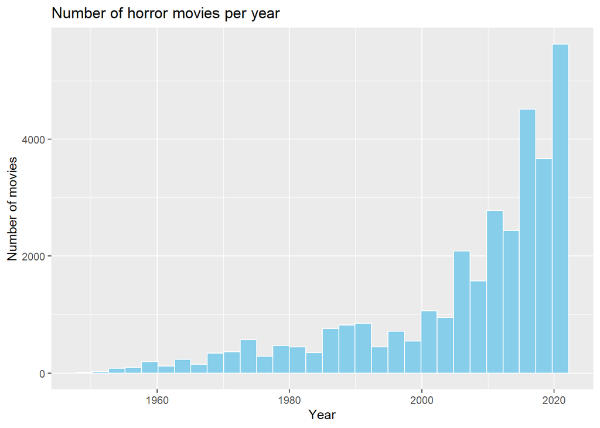

```r
ggplot(horror_movies, aes(x = year)) +
  geom_histogram(bins = 30, fill = "skyblue", color = "white") +
  labs(title = "Number of horror movies per year",
       x = "Year",
       y = "Number of movies")
```

```r
  theme_minimal()
```

[output not shown]

[output cut: 240 more lines]

[output not shown]

## Filtering out movies less voted for and exploring average ratings

```r
horror_movies <- horror_movies %>%
  filter(vote_count > 1000)

summary(horror_movies$vote_count)
```

```
##    Min. 1st Qu.  Median    Mean 3rd Qu.    Max.
##    1013    1309    1935    2689    3224   16900
```

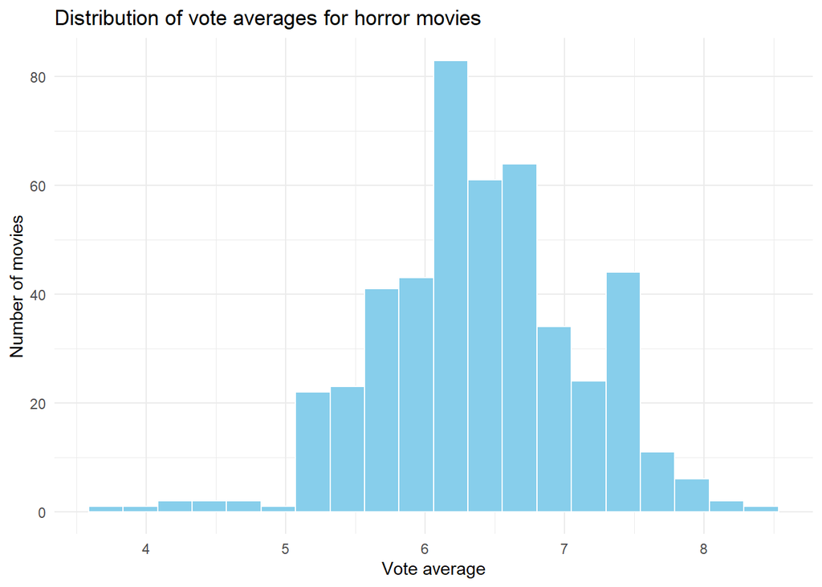

```r
ggplot(horror_movies, aes(x = vote_average)) +
  geom_histogram(bins = 20, fill = "skyblue", color = "white") +
  labs(title = "Distribution of vote averages for horror movies",
       x = "Vote average",
       y = "Number of movies") +
  theme_minimal()
```

### What are the top 10 movies based on the average vote?

```r
horror_movies %>%
  arrange(desc(vote_average)) %>%
  select(title, vote_average) %>%
  head(10)
```

```
## # A tibble: 10 × 2
##    title           vote_average
##    <chr>                  <dbl>
##  1 Psycho                   8.4
##  2 The Shining              8.2
##  3 Alien                    8.1
##  4 The Thing                8
##  5 The Black Phone          7.9
##  6 Train to Busan           7.8
##  7 I Saw the Devil          7.8
##  8 Rosemary's Baby          7.8
##  9 Deep Red                 7.8
## 10 The Exorcist             7.7
```

## What are the co-occuring genres in horror movies?

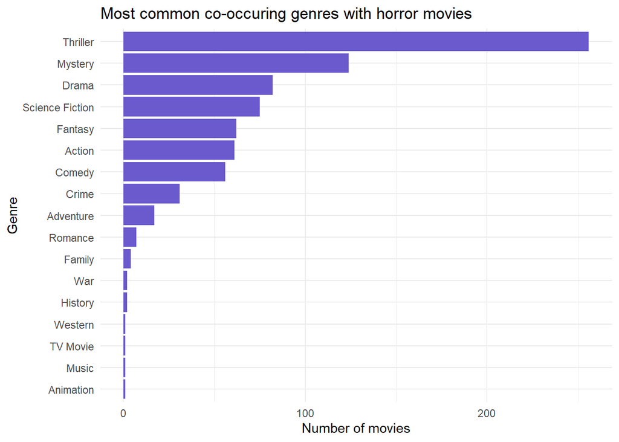

```r
horror_movies %>% #What is the most common co-oocuring genre with horror movies
  separate_rows(genre_names, sep = ", ") %>%
  rename(genre = genre_names) %>%
  filter(genre != "Horror") %>%
  count(genre) %>%
  ggplot(aes(x = n, y = fct_reorder(genre, n))) +
  geom_col(fill = "slateblue") +
  labs(title = "Most common co-occuring genres with horror movies",
       x = "Number of movies",
       y = "Genre") +
  theme_minimal()
```

## Exploring budget and revenue ### Removing missing data from the budget and revenue variables

```r
horror_movies <- horror_movies %>%
  filter(budget > 0, revenue > 0)
```

## Checking budget vs revenue with scatterplot

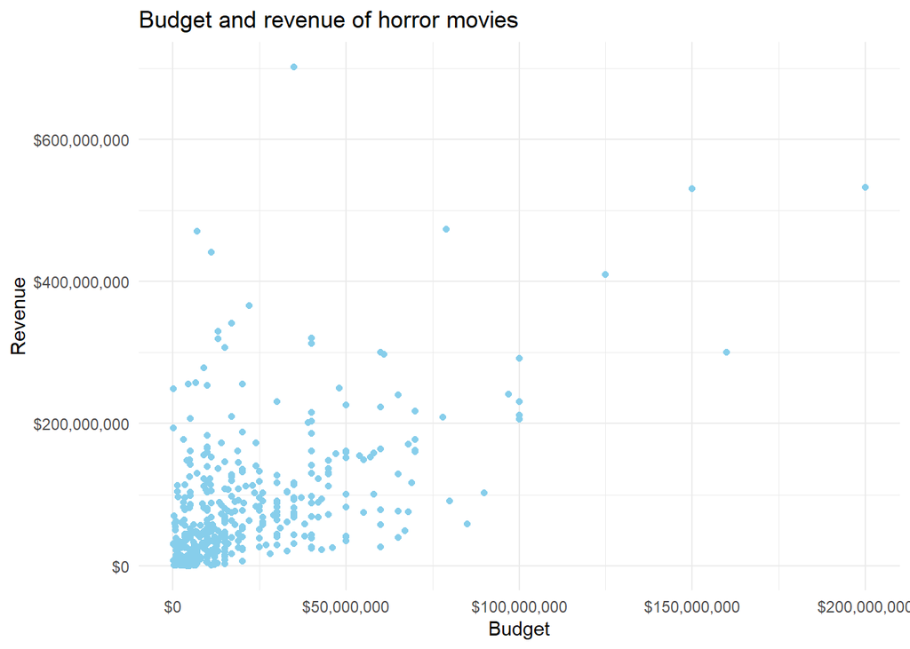

```r
ggplot(horror_movies, aes(x = budget, y = revenue)) +
  geom_point(color = "skyblue") +
  scale_x_continuous(labels = scales::dollar) +
  scale_y_continuous(labels = scales::dollar) +
  labs(title = "Budget and revenue of horror movies",
       x = "Budget",
       y = "Revenue") +
  theme_minimal()
```

### What movie was the most expensive to make?###

```r
horror_movies %>%
  arrange(desc(budget)) %>%
  select(title, budget) %>%
  head(1)
```

```
## # A tibble: 1 × 2
##   title          budget
##   <chr>           <dbl>
## 1 World War Z 200000000
```

### What movie had the highest revenue?

```r
horror_movies %>%
  arrange(desc(revenue)) %>%
  select(title, revenue) %>%
  head(1)
```

```
## # A tibble: 1 × 2
##   title   revenue
##   <chr>     <dbl>
## 1 It    701842551
```

### How much did that movie cost?

```r
horror_movies %>%
  filter(title == "It") %>%
  select(title, budget)
```

```
## # A tibble: 1 × 2
##   title   budget
##   <chr>    <dbl>
## 1 It    35000000
```

# Model building

Assuming that a higher budget results in a higher quality movie that could be more enjoyable for the audiance, the average vote of the horror movies could be predicted based on budget.

```r
modelA <- lm(vote_average ~ budget,
             data = horror_movies)
summary(modelA)
```

```
##
## Call:
## lm(formula = vote_average ~ budget, data = horror_movies)
##
## Residuals:
##      Min       1Q   Median       3Q      Max
## -2.06286 -0.45493 -0.00979  0.49494  1.91686
##
## Coefficients:
##               Estimate Std. Error t value Pr(>|t|)
## (Intercept)  6.486e+00  4.604e-02 140.855   <2e-16 ***
## budget      -3.069e-09  1.377e-09  -2.229   0.0264 *
## ---
## Signif. codes:  0 '***' 0.001 '**' 0.01 '*' 0.05 '.' 0.1 ' ' 1
##
## Residual standard error: 0.6827 on 394 degrees of freedom
## Multiple R-squared:  0.01245,    Adjusted R-squared:  0.009942
## F-statistic: 4.967 on 1 and 394 DF,  p-value: 0.0264
```

The results show, that the regression model is statistically significant (*F = 4.967*, *p < 0.05*), but it explains only 1.25% of the variance (*R^2 = 0.0125*).

## What other predictors could explain the averahe vote of a horror movie?

```r
modelB <- lm(vote_average ~ budget +
               vote_count +
               revenue,
             data = horror_movies)
summary(modelB)
```

```
##
## Call:
## lm(formula = vote_average ~ budget + vote_count + revenue, data = horror_movies)
##
## Residuals:
##      Min       1Q   Median       3Q      Max
## -1.96586 -0.38325 -0.02784  0.40390  1.60451
##
## Coefficients:
##               Estimate Std. Error t value Pr(>|t|)
## (Intercept)  6.129e+00  5.199e-02 117.889  < 2e-16 ***
## budget      -3.506e-09  1.427e-09  -2.457  0.01445 *
## vote_count   1.720e-04  1.664e-05  10.336  < 2e-16 ***
## revenue     -1.477e-09  4.756e-10  -3.104  0.00204 **
## ---
## Signif. codes:  0 '***' 0.001 '**' 0.01 '*' 0.05 '.' 0.1 ' ' 1
##
## Residual standard error: 0.5975 on 392 degrees of freedom
## Multiple R-squared:  0.2473, Adjusted R-squared:  0.2415
## F-statistic: 42.93 on 3 and 392 DF,  p-value: < 2.2e-16
```

The results show, that the more complex model using multiple predictors is statistically significant (*F = 42.93*, *p < 0.01*), and it explains 24.7% of the variance (*R^2 = 0.24*). The model is better than the simple model.

# Comparing the two models

```r
anova(modelA, modelB)
```

```
## Analysis of Variance Table
##
## Model 1: vote_average ~ budget
## Model 2: vote_average ~ budget + vote_count + revenue
##   Res.Df    RSS Df Sum of Sq      F    Pr(>F)
## 1    394 183.61
## 2    392 139.94  2    43.664 61.154 < 2.2e-16 ***
## ---
## Signif. codes:  0 '***' 0.001 '**' 0.01 '*' 0.05 '.' 0.1 ' ' 1
```

The results of the ANOVA test show, that adding **vote_count** and **revenue** variables as predictors to the model significantly improved the model fit (*F = 61.15, p < 0.01*), and that the more complex model explains more variability (*RSS = 139.94*).

# Checking for outliers in modelA

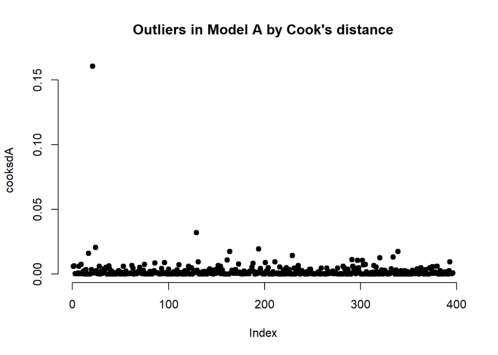

```r
cooksdA <- cooks.distance(modelA)
plot(cooksdA, pch = 19, frame = FALSE, main = "Outliers in Model A by Cook's distance")
```

# Checking for outliers in modelB

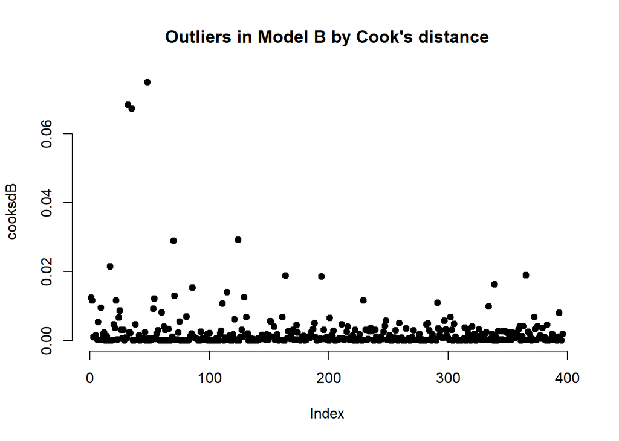

```r
cooksdB <- cooks.distance(modelB)
plot(cooksdB, pch = 19, frame = FALSE, main = "Outliers in Model B by Cook's distance")
```

# Residual diagnostics, assumption checks for the first, simple model (modelA)

## Checking normalitiy

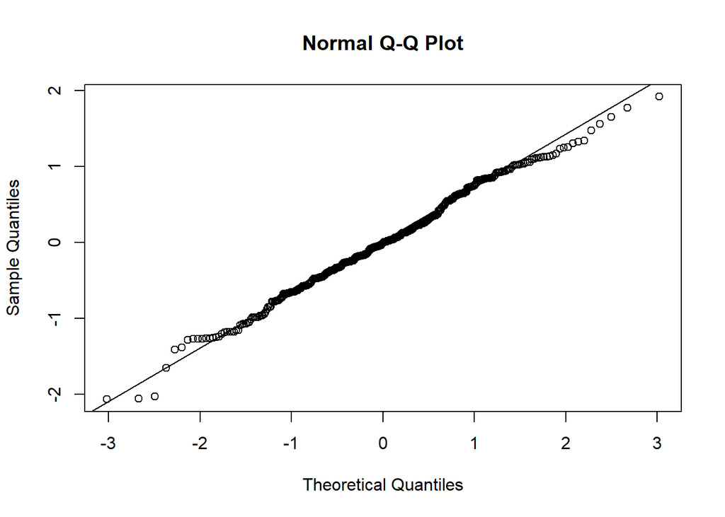

```r
qqnorm(residuals(modelA))
qqline(residuals(modelA))
```

## Checking homoscedasticity

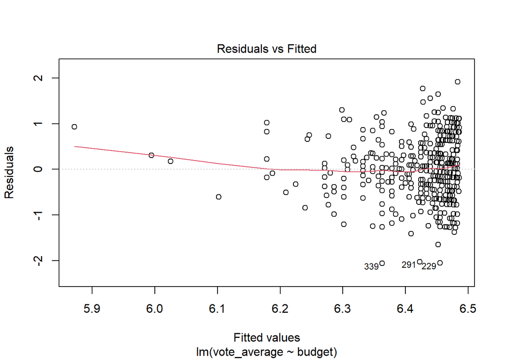

```r
plot(modelA, which = 1)
```

# Residual diagnostics, assumption checks for the second, multiple model (modelB)

## Checking normalitiy

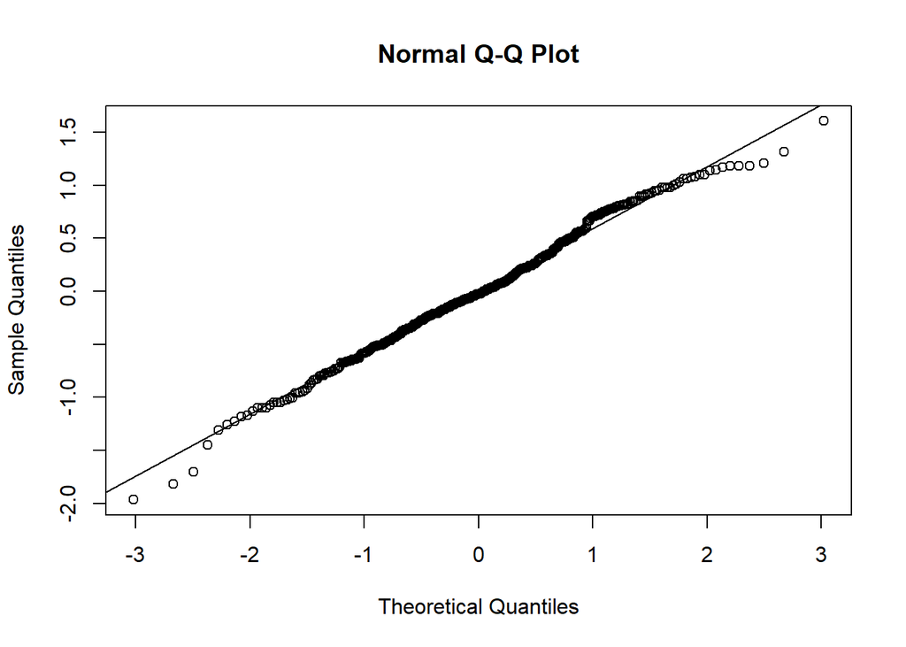

```r
qqnorm(residuals(modelB))
qqline(residuals(modelB))
```

## Checking homoscedasticity

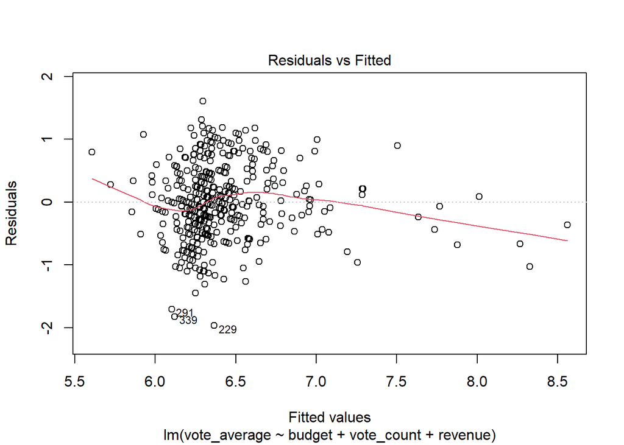

```r
plot(modelB, which = 1)
```

## Checking multicollinearity for the multiple regression model

```r
vif(modelB)
```

```
##     budget vote_count    revenue
##   1.401935   1.642385   2.146422
```

All values are under 3, thus the assumption is not violated.

# Conclusins

The analysis of the dataset about horror movies showed that how people find a movie’s quaility and likeability (*idicated by the averahe vote a movie recieves*) is influenced by the budget, but revenue and the number of votes are better predictors of this.